# Table of Contents

```python
print('\nEnabling interactive shell outputs ...')
print('   Use command pass; to disable cell text outputs')
from IPython.core.interactiveshell import InteractiveShell
InteractiveShell.ast_node_interactivity = "all"


import warnings
warnings.filterwarnings('ignore')
warnings.simplefilter(action="ignore",category=UserWarning)
warnings.simplefilter(action="ignore",category=FutureWarning)

import matplotlib.pyplot as plt
%matplotlib inline
%config InlineBackend.figure_formats = {'png', 'retina'}
```

```
Enabling interactive shell outputs ...
   Use command pass; to disable cell text outputs
```

## Question 1

```python
import pandas as pd


tensile_df = pd.DataFrame(data={'Strength':[160, 171, 175, 182, 184, 181, 188, 193, 195, 200],
                                'Hardwood':[10, 15, 15, 20, 20, 20, 25, 25, 28, 30]})
```

(a) Fit a linear regression model relating strength to percent hardwood.  
(b) Test the model for the significance of regression  
(c) Find a 95 percent c.i. on $\beta_1$

```python
from statsmodels.formula.api import ols

formula = 'Strength ~ Hardwood'
ols(formula, data=tensile_df).fit().summary2()
```

| Model: | OLS | Adj. R-squared: | 0.966 |
| --- | --- | --- | --- |
| Dependent Variable: | Strength | AIC: | 45.9456 |
| Date: | 2021-09-19 14:03 | BIC: | 46.5507 |
| No. Observations: | 10 | Log-Likelihood: | -20.973 |
| Df Model: | 1 | F-statistic: | 260.0 |
| Df Residuals: | 8 | Prob (F-statistic): | 2.20e-07 |
| R-squared: | 0.970 | Scale: | 4.8541 |

|  | Coef. | Std.Err. | t | P>\|t\| | [0.025 | 0.975] |
| --- | --- | --- | --- | --- | --- | --- |
| Intercept | 143.8244 | 2.5215 | 57.0386 | 0.0000 | 138.0097 | 149.6390 |
| Hardwood | 1.8786 | 0.1165 | 16.1245 | 0.0000 | 1.6100 | 2.1473 |

| Omnibus: | 1.211 | Durbin-Watson: | 2.132 |
| --- | --- | --- | --- |
| Prob(Omnibus): | 0.546 | Jarque-Bera (JB): | 0.701 |
| Skew: | 0.157 | Prob(JB): | 0.704 |
| Kurtosis: | 1.742 | Condition No.: | 78 |

The model and the coefficients are significant. The 95\% c.i. on $\beta_1$ is [1.61, 2.147].

## Question 2:

A sample of 25 brands of cigarette has been tested for tar and nicotine contents,  
carbonmonoxide (mgs) emitted by cigarette smoke, and cigarette weight (g).  
Past studies have shown that the amount CO emitted increases with the tar and nicotine content.

a) Model the CO emitted by cigratte as a linear function of the other three quantities.  
Which variables are significant and not significant in the model ? What are the fitted model coefficients ?

### Solution a)

```python
import pandas as pd

co_data = pd.read_excel('data/lect02-lin-reg.xlsx', sheet_name='CO-smoke',header=0)
co_data
```

|  | TAR | NICOTINE | WEIGHT | CO |
| --- | --- | --- | --- | --- |
| 0 | 14.1 | 0.86 | 0.9853 | 13.6 |
| 1 | 16.0 | 1.06 | 1.0938 | 16.6 |
| 2 | 29.8 | 2.03 | 1.1650 | 23.5 |
| 3 | 8.0 | 0.67 | 0.9280 | 10.2 |
| 4 | 4.1 | 0.40 | 0.9462 | 5.4 |
| 5 | 15.0 | 1.04 | 0.8885 | 15.0 |
| 6 | 8.8 | 0.76 | 1.0267 | 9.0 |
| 7 | 12.4 | 0.95 | 0.9225 | 12.3 |
| 8 | 16.6 | 1.12 | 0.9372 | 16.3 |
| 9 | 14.9 | 1.02 | 0.8858 | 15.4 |
| 10 | 13.7 | 1.01 | 0.9643 | 13.0 |
| 11 | 15.1 | 0.90 | 0.9316 | 14.4 |
| 12 | 7.8 | 0.57 | 0.9705 | 10.0 |
| 13 | 11.4 | 0.78 | 1.1240 | 10.2 |
| 14 | 9.0 | 0.74 | 0.8517 | 9.5 |
| 15 | 1.0 | 0.13 | 0.7851 | 1.5 |
| 16 | 17.0 | 1.26 | 0.9186 | 18.5 |
| 17 | 12.8 | 1.08 | 1.0395 | 12.6 |
| 18 | 15.8 | 0.96 | 0.9573 | 17.5 |
| 19 | 4.5 | 0.42 | 0.9106 | 4.9 |
| 20 | 14.5 | 1.01 | 1.0070 | 15.9 |
| 21 | 7.3 | 0.61 | 0.9806 | 8.5 |
| 22 | 8.6 | 0.69 | 0.9693 | 10.6 |
| 23 | 15.2 | 1.02 | 0.9496 | 13.9 |
| 24 | 12.0 | 0.82 | 1.1184 | 14.9 |

```python
from statsmodels.formula.api import ols

formula = 'CO ~ TAR + NICOTINE + WEIGHT'
ols(formula, data=co_data).fit().summary2()
```

| Model: | OLS | Adj. R-squared: | 0.907 |
| --- | --- | --- | --- |
| Dependent Variable: | CO | AIC: | 93.0187 |
| Date: | 2021-09-02 08:45 | BIC: | 97.8942 |
| No. Observations: | 25 | Log-Likelihood: | -42.509 |
| Df Model: | 3 | F-statistic: | 78.98 |
| Df Residuals: | 21 | Prob (F-statistic): | 1.33e-11 |
| R-squared: | 0.919 | Scale: | 2.0901 |

|  | Coef. | Std.Err. | t | P>\|t\| | [0.025 | 0.975] |
| --- | --- | --- | --- | --- | --- | --- |
| Intercept | 3.2022 | 3.4618 | 0.9250 | 0.3655 | -3.9969 | 10.4013 |
| TAR | 0.9626 | 0.2422 | 3.9736 | 0.0007 | 0.4588 | 1.4663 |
| NICOTINE | -2.6317 | 3.9006 | -0.6747 | 0.5072 | -10.7433 | 5.4800 |
| WEIGHT | -0.1305 | 3.8853 | -0.0336 | 0.9735 | -8.2105 | 7.9495 |

| Omnibus: | 0.052 | Durbin-Watson: | 2.860 |
| --- | --- | --- | --- |
| Prob(Omnibus): | 0.974 | Jarque-Bera (JB): | 0.223 |
| Skew: | -0.087 | Prob(JB): | 0.895 |
| Kurtosis: | 2.572 | Condition No.: | 242 |

**Since the intercept is not significant, refit without intercept**

```python
from statsmodels.formula.api import ols

formula = 'CO ~ TAR + NICOTINE + WEIGHT -1'
ols(formula, data=co_data).fit().summary2()
```

| Model: | OLS | Adj. R-squared (uncentered): | 0.988 |
| --- | --- | --- | --- |
| Dependent Variable: | CO | AIC: | 92.0171 |
| Date: | 2021-09-02 08:46 | BIC: | 95.6737 |
| No. Observations: | 25 | Log-Likelihood: | -43.009 |
| Df Model: | 3 | F-statistic: | 709.1 |
| Df Residuals: | 22 | Prob (F-statistic): | 4.97e-22 |
| R-squared (uncentered): | 0.990 | Scale: | 2.0764 |

|  | Coef. | Std.Err. | t | P>\|t\| | [0.025 | 0.975] |
| --- | --- | --- | --- | --- | --- | --- |
| TAR | 0.9367 | 0.2398 | 3.9056 | 0.0008 | 0.4393 | 1.4341 |
| NICOTINE | -2.4959 | 3.8850 | -0.6425 | 0.5272 | -10.5529 | 5.5610 |
| WEIGHT | 3.3499 | 0.9661 | 3.4675 | 0.0022 | 1.3464 | 5.3534 |

| Omnibus: | 0.689 | Durbin-Watson: | 2.938 |
| --- | --- | --- | --- |
| Prob(Omnibus): | 0.708 | Jarque-Bera (JB): | 0.380 |
| Skew: | -0.298 | Prob(JB): | 0.827 |
| Kurtosis: | 2.896 | Condition No.: | 184 |

b) Remove the most significant variable in a) and refit the model.  
How do the model coefficients and your conclusion about the significance of variables change compared to a) ?

### Solution b)

Remove TAR and refit. Now Nicotine and Weight have positive coefficients compared to the first model.  
But only Nicotine is significant and the $R^2$ reduces somewhat.  
The changes in the coefficient values and significances are due to correlation  
between TAR and Nicotine as shown in the scatter diagram and correlation matrix.

```python
formula = 'CO ~ NICOTINE + WEIGHT - 1'
ols(formula, data=co_data).fit().summary2()
```

| Model: | OLS | Adj. R-squared (uncentered): | 0.981 |
| --- | --- | --- | --- |
| Dependent Variable: | CO | AIC: | 103.1850 |
| Date: | 2021-09-02 08:47 | BIC: | 105.6227 |
| No. Observations: | 25 | Log-Likelihood: | -49.592 |
| Df Model: | 2 | F-statistic: | 652.0 |
| Df Residuals: | 23 | Prob (F-statistic): | 5.58e-21 |
| R-squared (uncentered): | 0.983 | Scale: | 3.3632 |

|  | Coef. | Std.Err. | t | P>\|t\| | [0.025 | 0.975] |
| --- | --- | --- | --- | --- | --- | --- |
| NICOTINE | 12.2512 | 1.1636 | 10.5286 | 0.0000 | 9.8441 | 14.6583 |
| WEIGHT | 1.8341 | 1.1260 | 1.6289 | 0.1169 | -0.4951 | 4.1633 |

| Omnibus: | 0.142 | Durbin-Watson: | 2.747 |
| --- | --- | --- | --- |
| Prob(Omnibus): | 0.932 | Jarque-Bera (JB): | 0.340 |
| Skew: | 0.115 | Prob(JB): | 0.844 |
| Kurtosis: | 2.477 | Condition No.: | 6 |

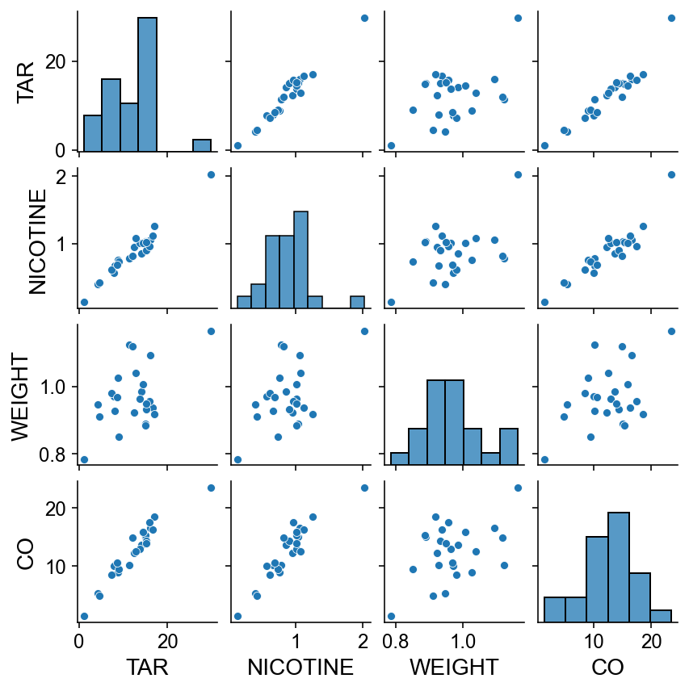

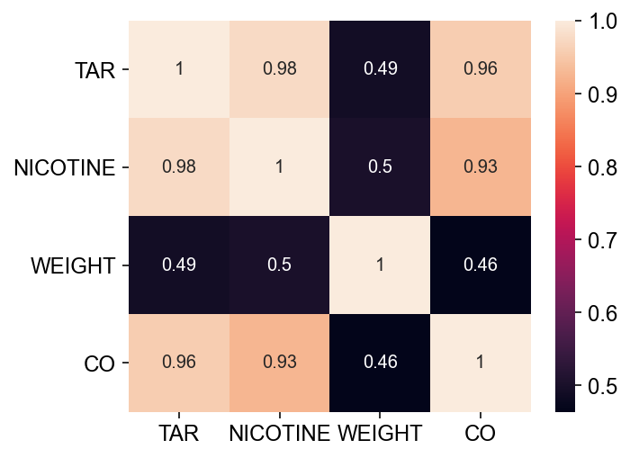

```python
import seaborn as sns

plt.figure();
sns.pairplot(co_data,height=1.5, aspect=1);

plt.figure(figsize=(5,4));
corr = co_data.corr()
sns.heatmap(corr, xticklabels=corr.columns, yticklabels=corr.columns,
            annot=True);
pass;
```